# Efecto Airbnb en Bilbao: hosts

Este informe se ha generado automáticamente con R a partir del [script de Rmarkdown](https://github.com/montera34/airbneuskadi/tree/master/analisis/hosts-analysis.Rmd) disponible en el [repositorio airbnbeuskadi](https://github.com/montera34/airbneuskadi).

## Datos

- Datahippo.com Bilbao
- Fecha scraping: 2018-09-26

## Resumen

En **Bilbao** se han publicado 1.450 anuncios de Airbnb desde que Datahippo guarda registro, que han tenido capacidad para 4.845 plazas (accommodates).

De esos anuncios 0 tienen rellena la parte de la licencia (lo que supone un 0,0% del municipio), lo que no quiere decir que todas esas licencias indicadas sean válidas.

Estos anuncios (listings, en la terminología de Airbnb) han sido publicados por 987 anfitriones.

PERO

De esos 1.450 anuncios han sido “encontrados” como disponibles por el scraping de Datahippo con fecha posterior (ver siguiente tabla):

[output not shown]

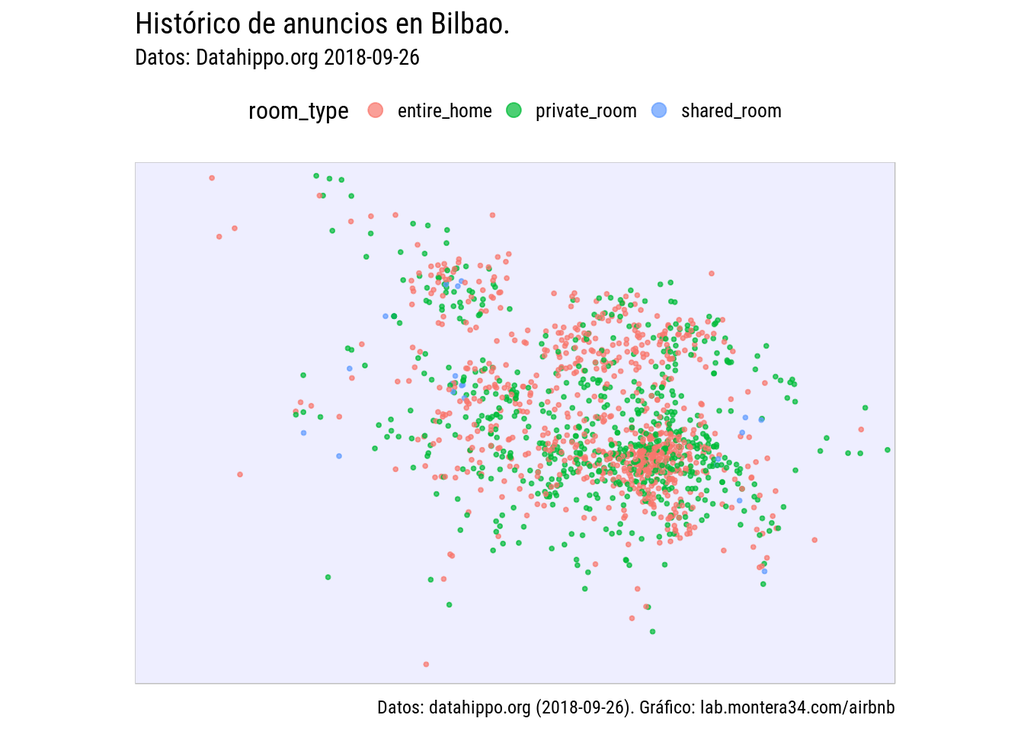

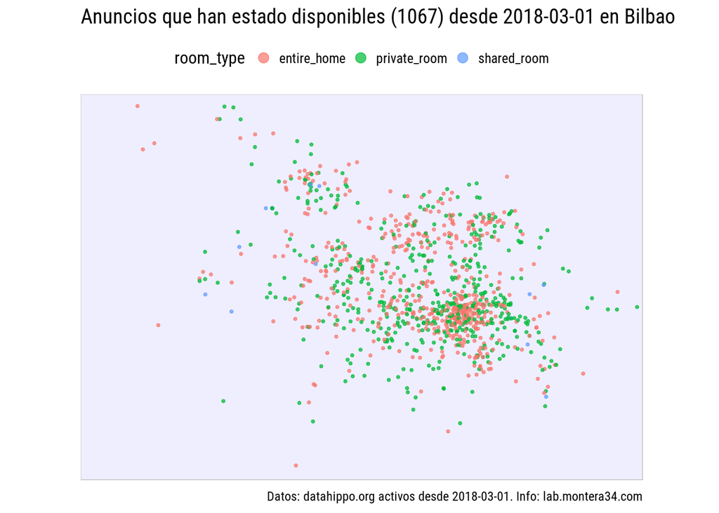

### Los anfitriones con más alojamientos

Calculado por anuncios activos desde 2018-03-01.

Los 25 anfitriones con más alojamientos

| host.id | alojamientos | plazas |
| --- | --- | --- |
| airbnb85246818 | 16 | 70 |
| airbnb62205707 | 15 | 25 |
| airbnb105663223 | 13 | 80 |
| airbnb38456322 | 7 | 26 |
| airbnb101618589 | 6 | 12 |
| airbnb10708165 | 6 | 10 |
| airbnb11296499 | 6 | 40 |
| airbnb97970926 | 6 | 29 |
| airbnb140766793 | 5 | 16 |
| airbnb148512835 | 5 | 18 |
| airbnb19274599 | 5 | 30 |
| airbnb3297234 | 5 | 27 |
| airbnb8721428 | 5 | 17 |
| airbnb119829105 | 4 | 9 |
| airbnb124256500 | 4 | 10 |
| airbnb135104966 | 4 | 8 |
| airbnb143548447 | 4 | 10 |
| airbnb16781355 | 4 | 12 |
| airbnb16828328 | 4 | 7 |
| airbnb17104681 | 4 | 21 |
| airbnb173492560 | 4 | 8 |
| airbnb181805690 | 4 | 8 |
| airbnb33293247 | 4 | 11 |
| airbnb37826234 | 4 | 12 |
| airbnb4743615 | 4 | 24 |

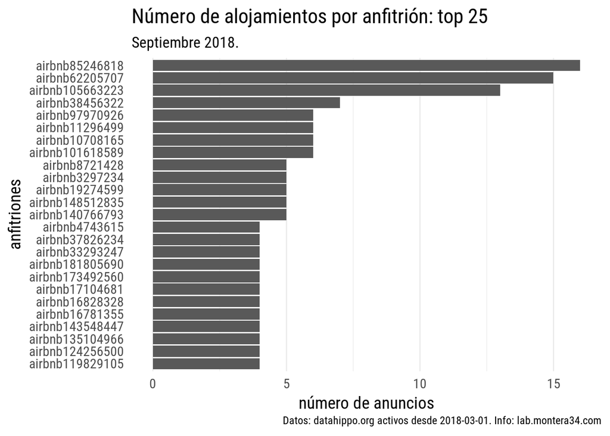

#### En el mapa

##### Top 5

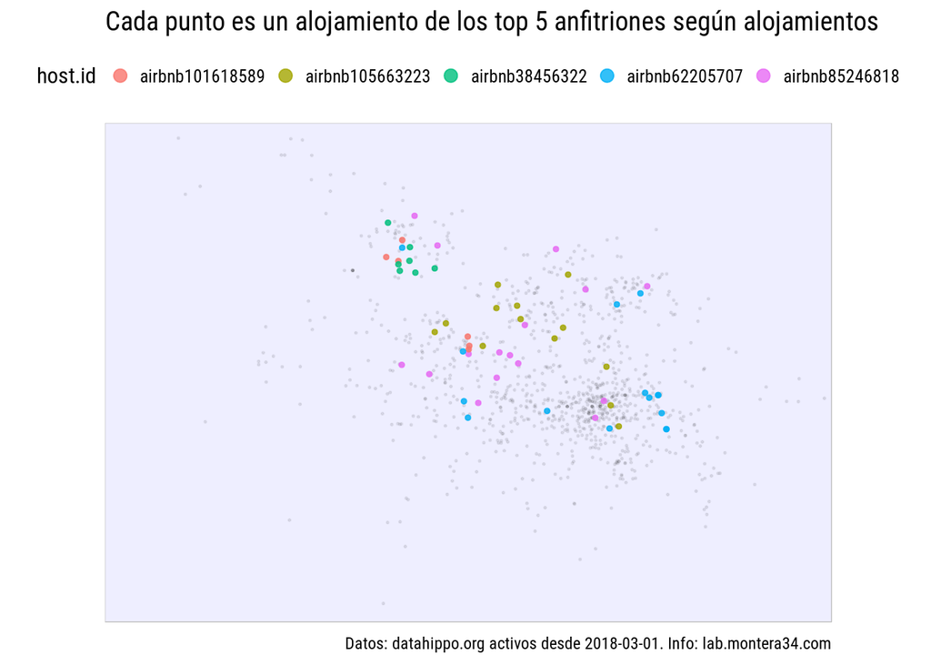

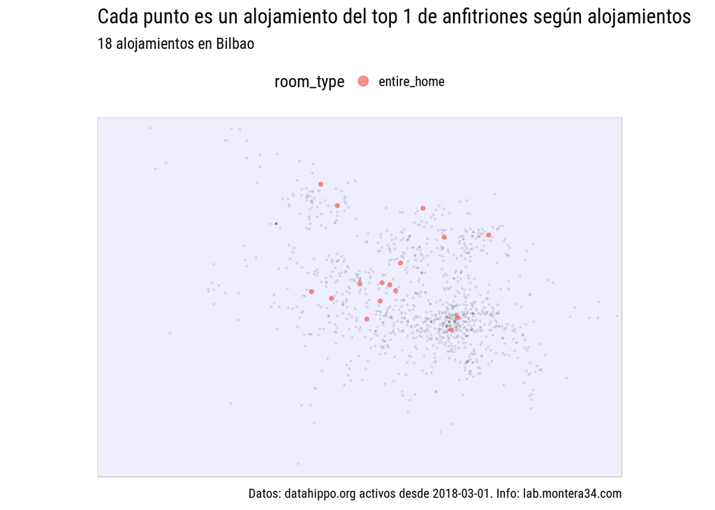

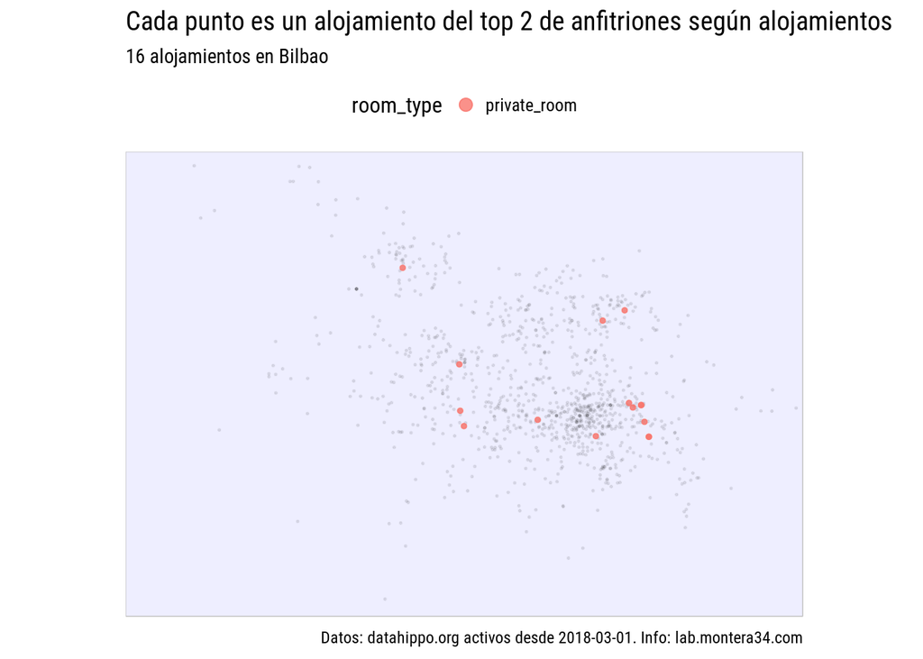

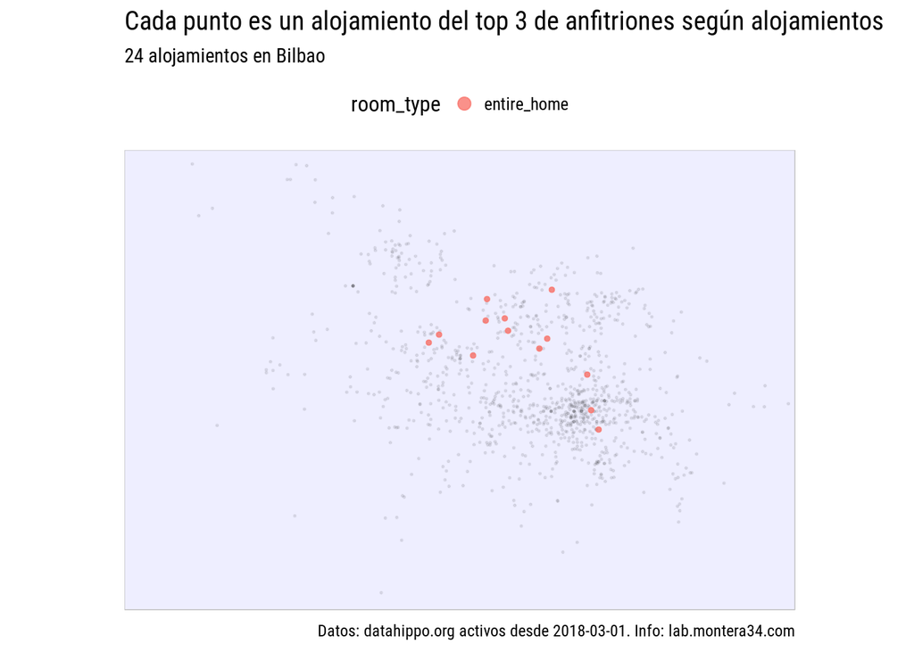

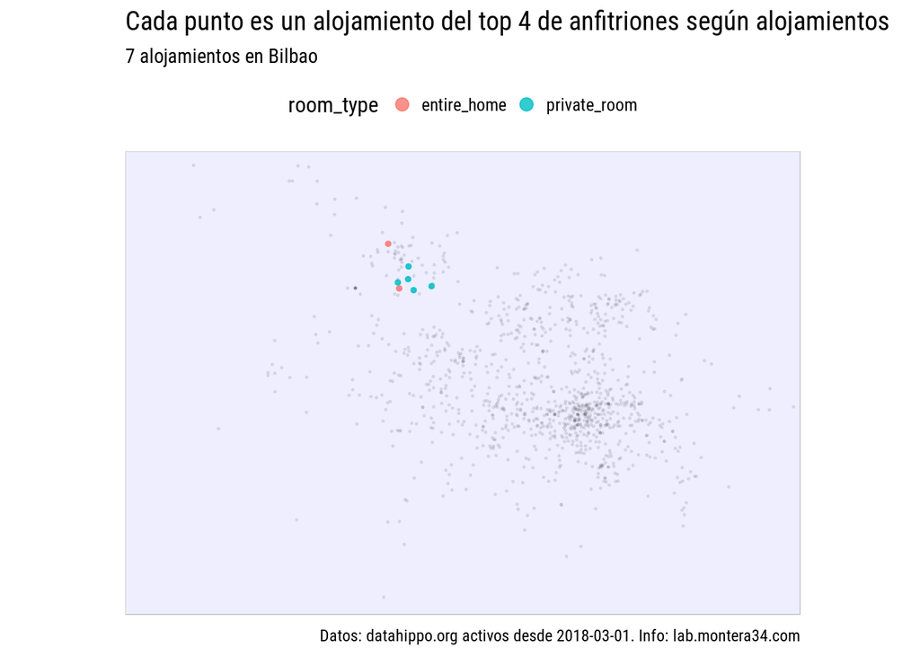

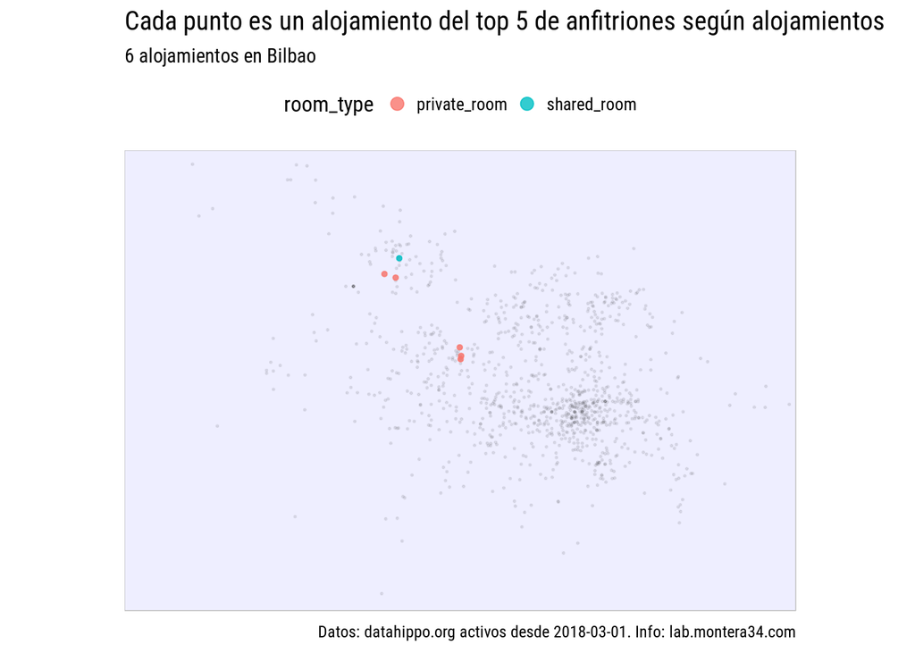

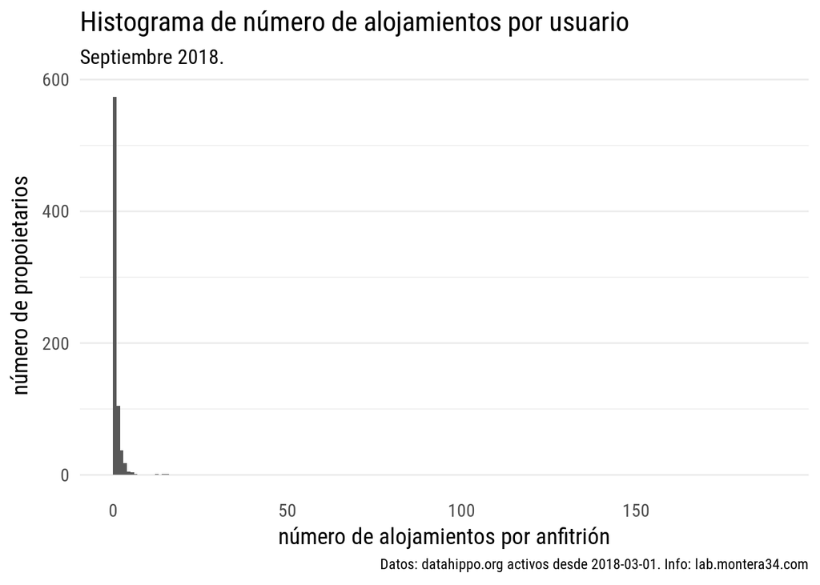

### Los anfitriones con más plazas

Los 30 anfitriones con más plazas

| host.id | plazas | alojamientos |
| --- | --- | --- |
| airbnb105663223 | 80 | 13 |
| airbnb85246818 | 70 | 16 |
| airbnb11296499 | 40 | 6 |
| airbnb19274599 | 30 | 5 |
| airbnb97970926 | 29 | 6 |
| airbnb7088275 | 28 | 4 |
| airbnb3297234 | 27 | 5 |
| airbnb38456322 | 26 | 7 |
| airbnb62205707 | 25 | 15 |
| airbnb4743615 | 24 | 4 |
| airbnb164277100 | 23 | 3 |
| airbnb499476 | 23 | 4 |
| airbnb17104681 | 21 | 4 |
| airbnb65042652 | 20 | 3 |
| airbnb130249915 | 18 | 3 |
| airbnb148512835 | 18 | 5 |
| airbnb82268887 | 17 | 4 |
| airbnb8721428 | 17 | 5 |
| airbnb140766793 | 16 | 5 |
| airbnb187108987 | 16 | 2 |
| airbnb3016474 | 16 | 1 |
| airbnb77957822 | 15 | 2 |
| airbnb40853483 | 14 | 2 |
| airbnb48671909 | 14 | 4 |
| airbnb3215084 | 13 | 3 |
| airbnb63591389 | 13 | 2 |
| airbnb101618589 | 12 | 6 |
| airbnb120092583 | 12 | 1 |
| airbnb138214482 | 12 | 2 |
| airbnb16781355 | 12 | 4 |

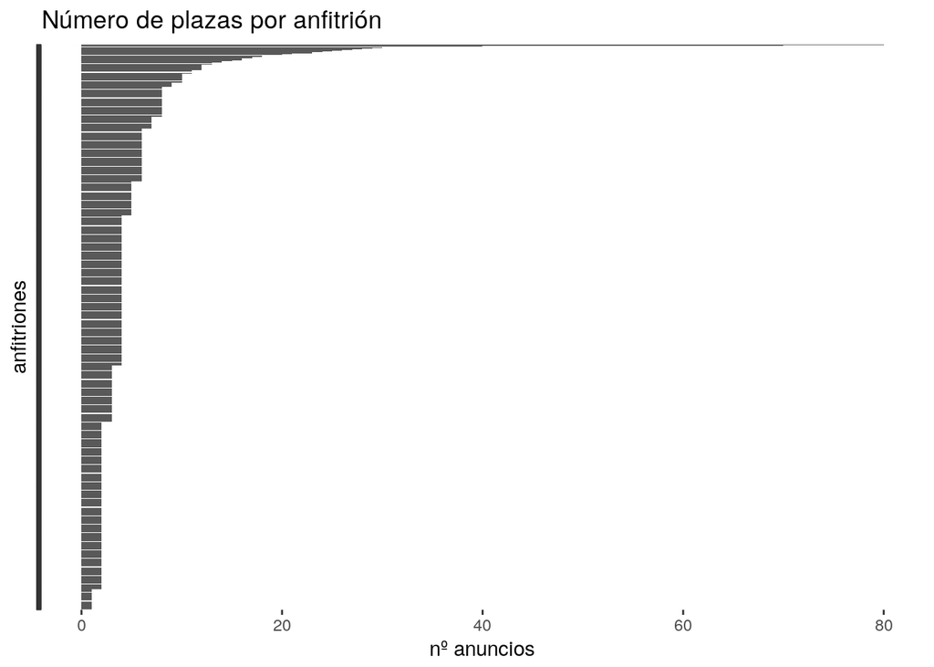

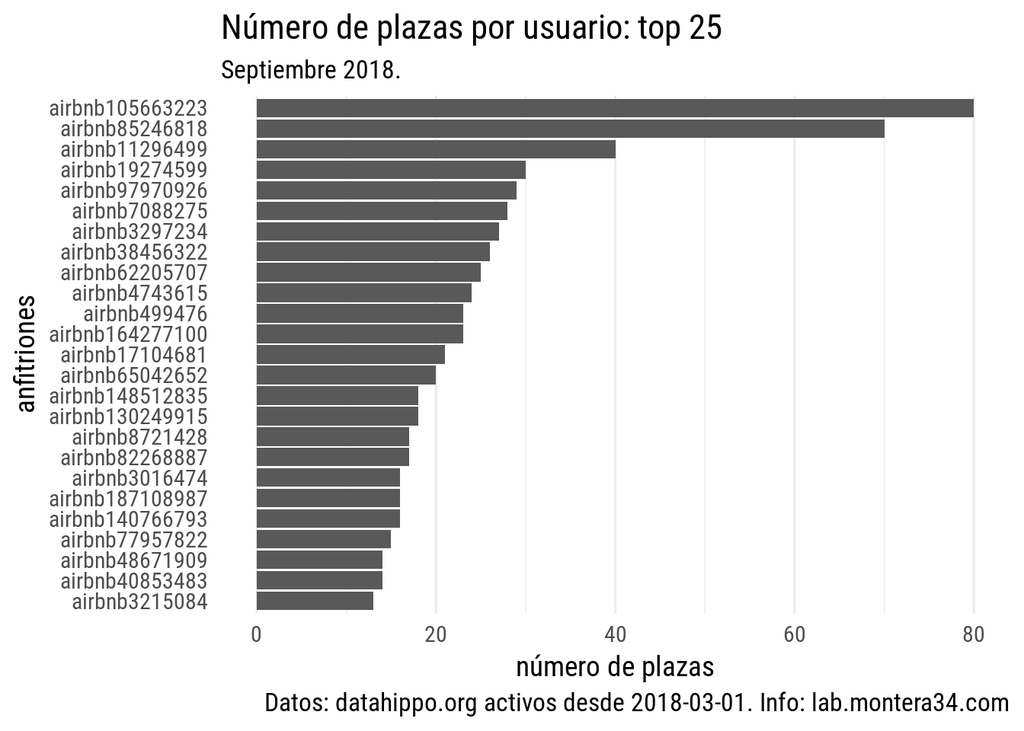